# Surveillance Systeme

Was ist das? Warum gibt es das?

Jakob Schumacher

## Vortrag als Webseite

[figure not shown]

## Das sollen Sie mitnehmen

- Surveillance ist wichtiger denn je
- Surveillance heißt: “Daten für Taten”
- Überblick über die Schritte
- Surveillance muss durchdefiniert werden
- Untererfassungspyramide

# Einleitung

## Was ist die Wahrheit?

Gesundheitsminister USA: *“Covid-19 greift bestimmte Rassen unverhältnismäßig stark an. Die Menschen, die am meisten immun sind, sind aschkenasische Juden und Chinesen“*

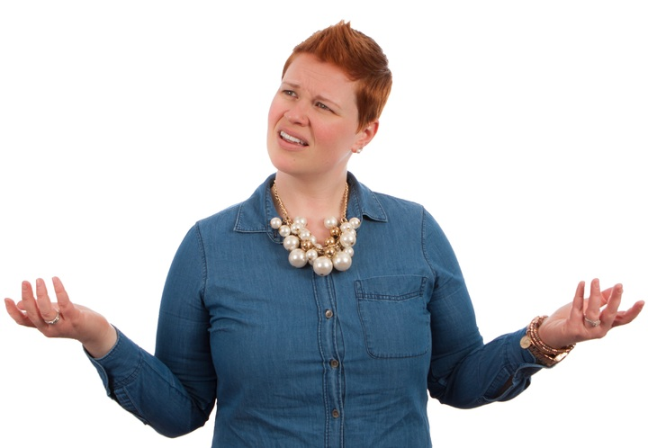

https://pxhere.com/es/photo/804575 - CC0

## Formen von Surveillance

- Gesellschaftliche Surveillance
- Rhizomatische Surveillance
- Top-Down Surveillance

## Abgrenzung

- Wissenschaft
- Evaluation
- Umfrage
- Anekdoten

## Definition

> Surveillance ist die fortlaufende, systematische Erfassung, Analyse und Interpretation gesundheitsbezogener Daten, die für die Planung, Durchführung und Bewertung der öffentlichen Gesundheitspraxis unerlässlich sind.

In aller Kürze:

> *Daten für Taten!*

## Ziele der Surveillance

- Maßnahmen für einen Fall
- Maßnahmen für die Bevölkerung
- Maßnahmen durch die Medizin
- Maßnahmen durch das Individuum
- Evaluierung von Maßnahmen
- Wissenschaftliche Erkenntnisse
- Erfüllung von Verpflichtung

# Schritte

## Events

- Events bestimmen “das Schicksal” des Systems
- Events sind das was gemessen wird, z.B.:
  - Ein Nachweis einer Krankheit
  - Eine Suchaufruf für den Begriff “Kopfweh”
  - Ein benutzes Kondom

## Sammeln

- Durch die Sammlung entstehen die Kosten
- Wird zwischen *aktiv* und *passiv* unterschieden

## Klassifizieren

- Die Klassifikation wird zu oft übersehen
- Zählen ist schwieriger als man denkt
- Wie viele EHEC-Fälle haben wir in der Kita?
  - Eine Person mit EHEC Nachweis und blutigem Durchfall
  - Zwei Personen mit EHEC Nachweis ohne Symptome
  - Ein Kind mit Durchfall
  - Drei Kinder sind als krank abgemeldet
  - Ein Kind fehlt unentschuldigt

## Daten managen

- Das Werkzeug der Surveillance-Spezialisten
- Beeinflusst die Qualität entscheidend

## Analysieren

- Daten werden zu “informationen” umgewandelt
- Mehrstufiger Prozess
  - Extraktion und Reinigung
  - Werte berechnet
  - Grafiken erstellt
  - Bewertet mit Kenntnis der Limitationen

## Vermitteln

- Die Informationen müssen übermittelt werden
- Traditioneller Weise: Bericht
- Modern: Socialmedia
- Bester Weg: unklar

## Handeln

- VORSICHT: Zählt im eigentlichen Sinne nicht zur Surveillance dazu
- Fallbasiertes Handeln
- Bevölkerungsbasiertes Handeln
- Medizinisches Handeln
- Personenbezogenes Handeln

# Typen

## Wichtige Typen von Surveillance

- Indicator-basierte Surveillance
- Event-basierte Surveillance
- Syndromische Surveillance
- Abwassersurveillance
- Sentinel vs. Gesamt
- Reservoir Surveillance
- Risikofaktor Surveillance

## Inidcator-basierte Surveillance

- “Klassische Surveillance”
- Ein *Indikator* ist z.B. ein Fall
- Üblicherweise: Arztmeldung/Labormeldung
- Bsp: Deutsches Meldewesen

## Beispiel: Deutsches Meldesystem

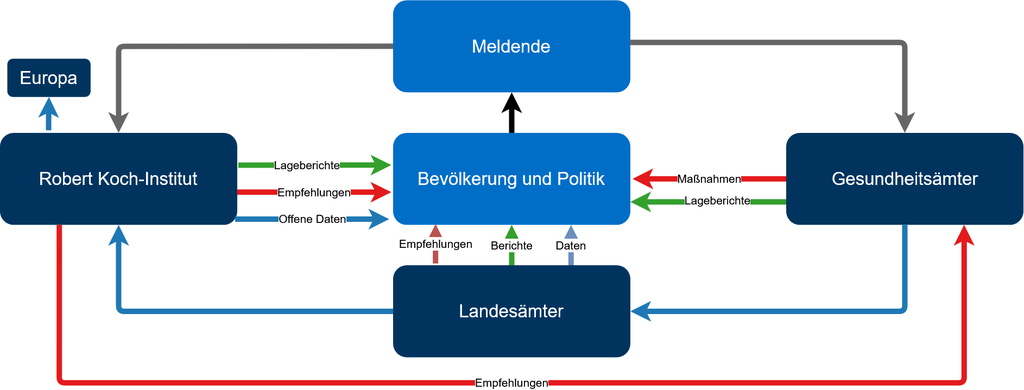

## Event-basierte Surveillance

- Erfasst alle möglichen Events
- Besteht aus einem System “Signale” zu erfassen
- Häufig eine Gruppe von Experten
- Bsp: Epilag

## Beispiel: Epilag

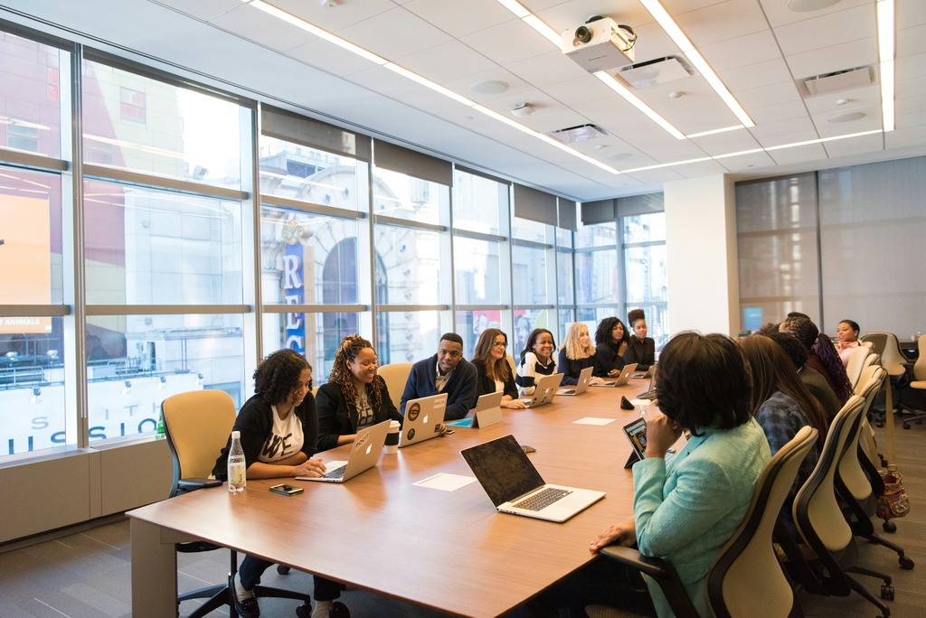

- Länder und RKI haben eine wöchentliche Telefonkonferenz
- Bericht über aktuelle Ereignisse
- Keine Indikatoren

[Bild: Christina auf wocintechchat.com](https://unsplash.com/de/@wocintechchat?utm_content=creditCopyText&utm_medium=referral&utm_source=unsplash)

## Syndromische Surveillance

- Erfasst Verhaltensweisen, die assoziiert sind mit Erkrankung
- Diverse Gruppe von Surveillancesystemen
- Bsp: Grippeweb

## Beispiel: Grippeweb

- Personen geben wöchentlich Auskunft
- Erfassung von Tests
- Abstriche

## Abwassersurveillance

- Abwasser wird untersucht auf Erreger
- Bsp: AMELAG

# Attribute

## Attribute

- Surveillancesysteme haben Vorteile und Nachteile
- Hier spricht man von Attributen
- Sind wichtig für die Evaluation

## Untererfassung

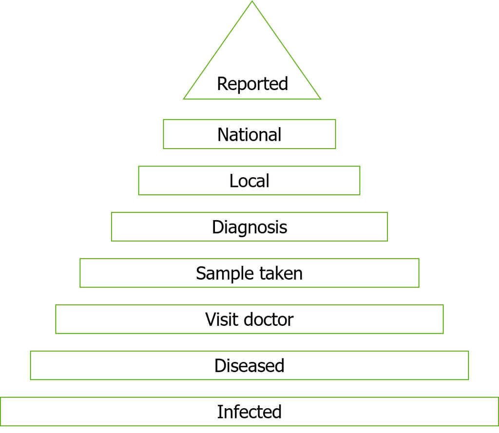

Underestimation pyramid

## Norovirus

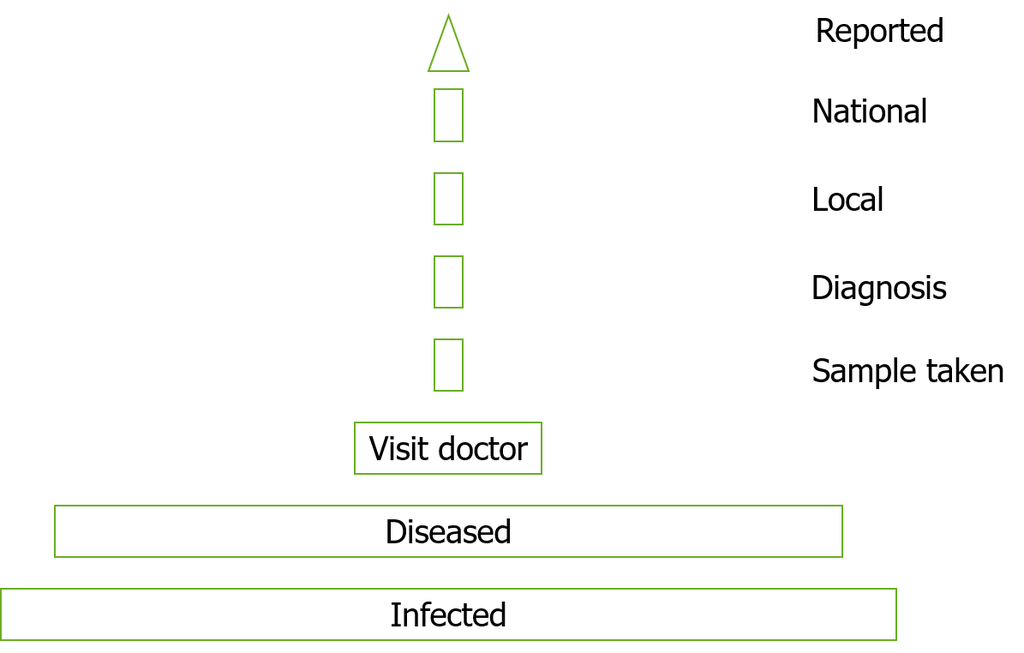

Underestimation pyramid

## Ebola

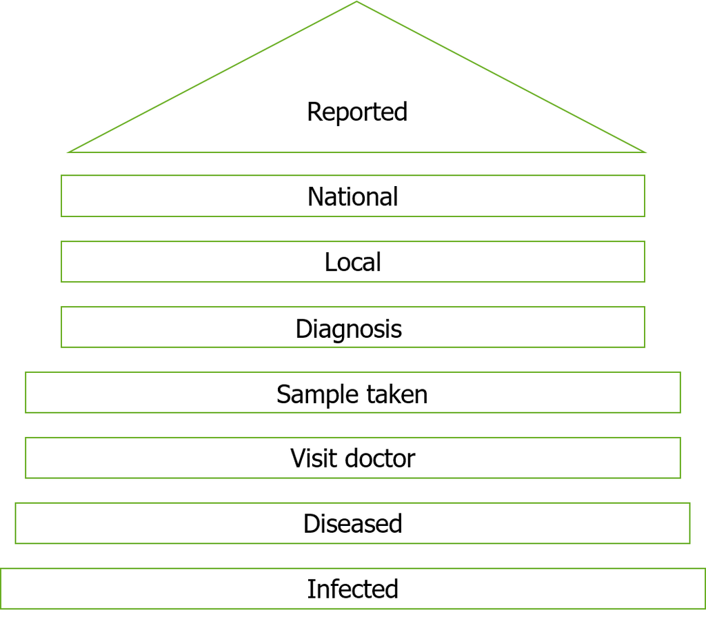

Underestimation pyramid

## Validität

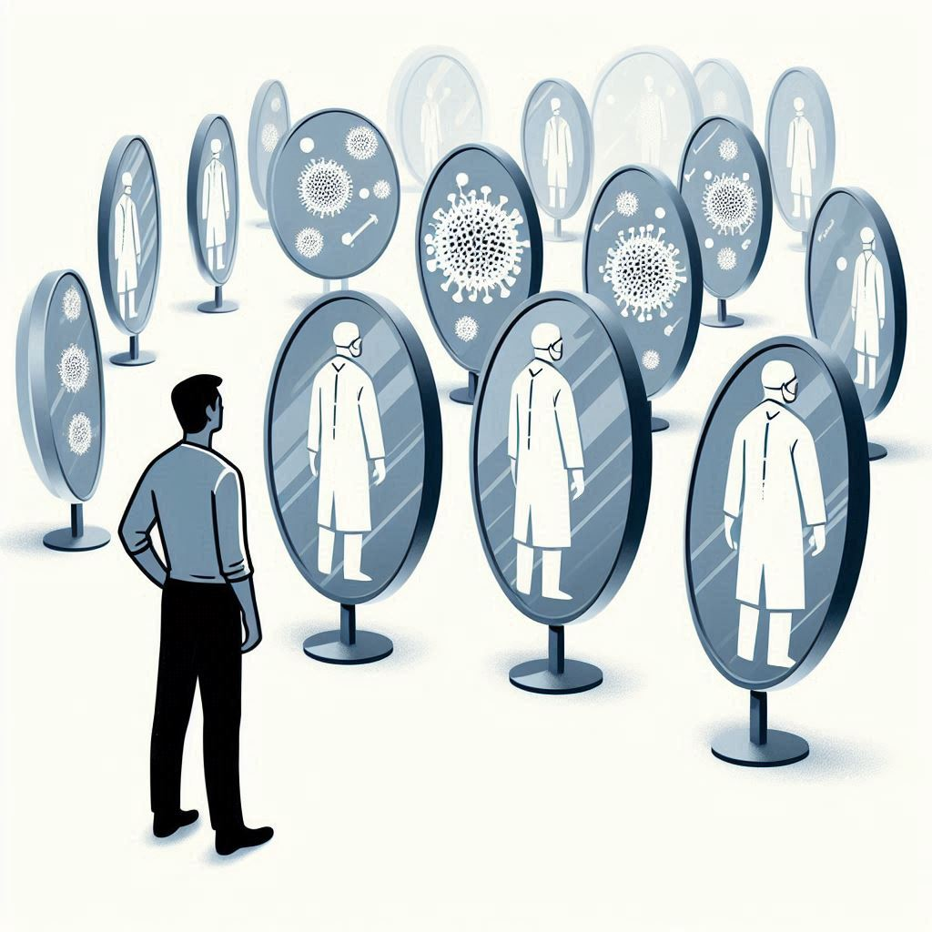

Sind wir uns sicher, dass wir alles richtig erkennen?

Bing image creator

## Timeliness

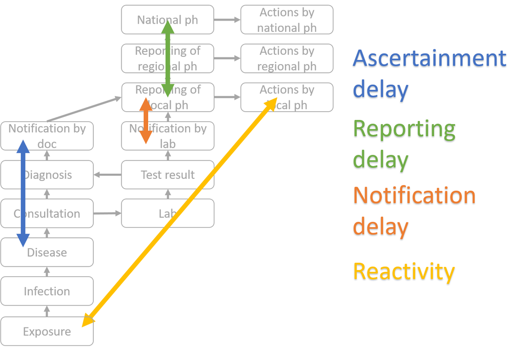

Zeitlichkeit

## Nützlichkeit

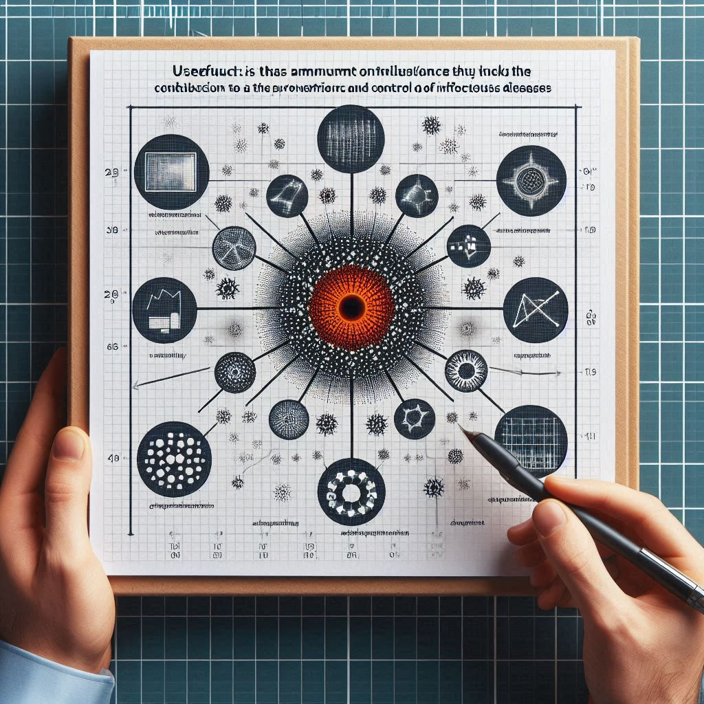

Wie nützlich ist die Surveillance

Bing image creator

## Jetzt sind Sie an der Reihe

Erstellen Sie ein gedankliches Surveillancesystem

- Schizophrenie
- Impfablehnung
- Zahnstatus
- Angriffe auf SpDi-Mitarbeitende
- Bleihaltige Kinderspielzeuge